# Berliner Hotels Don`t Have To Fear Airbnb - At Least For Now

[figure not shown]

Numerous Airbnb hosts signed up for the platform since its debut in summer 2011.

*Daniel Murphy & Paulo Kalkhake, Hertie School of Governance, Berlin*

#### Airbnb has changed the accomodation industry forever - and keeps growing

Airbnb and other short-term rental platforms for apartments have become hugely popular, offering accommodation that is cheaper, better located and more ‘authentic’ than hotels. Thus, it is no surprise that Airbnb sold about 15 million room nights in 2012 making them as big as some of the mid-level hotel chains. With its growing success, the effects of Airbnb on the Berlin housing market has recently been the subject of a great deal of scrutiny.

In 2014, the city passed a law that forbade renting out entire apartments to tourists on Airbnb. This came in response to an unprecedented 56 percent rise in rents in Berlin between 2009 and 2014, for which Airbnb and other online hosting platforms received some of the blame. The city’s law was widely welcomed by Berliners hoping to slow the forces of gentrification, but it was also welcomed by another Airbnb victim in Berlin; the hotel industry.

Airbnb claims that their service is complementary to hotels. However, data shows that the majority of Airbnb listings in most cities are entire homes, many of which are rented all year round - disrupting housing and hotels. According to a recent study from Boston University (Zervas, Proserpio, and Byers 2016), a ten percent increase in Airbnb supply results in a 0.35 percent decrease in hotel room revenue. This is mainly a result of price competition, as the researchers found that hotels are reducing prices in an effort to stay in the race.

With that debate in mind we looked at what the data on 15,368 listed apartments between 2010 and 2014 might tell us on how hotels in Berlin are dealing with the upcoming star in the hospitality industry. Browse our results below, and see for yourself.

#### How big is Airbnb in Berlin?

Airbnb`s popularity in Berlin has exploded since it’s official debut in the city in June 2011. To answer this questions we made a couple of simplifying assumptions. First, we said that an apartment is listed six month before its first guest review. We then calculated the cumulative sum per neighbourhood.

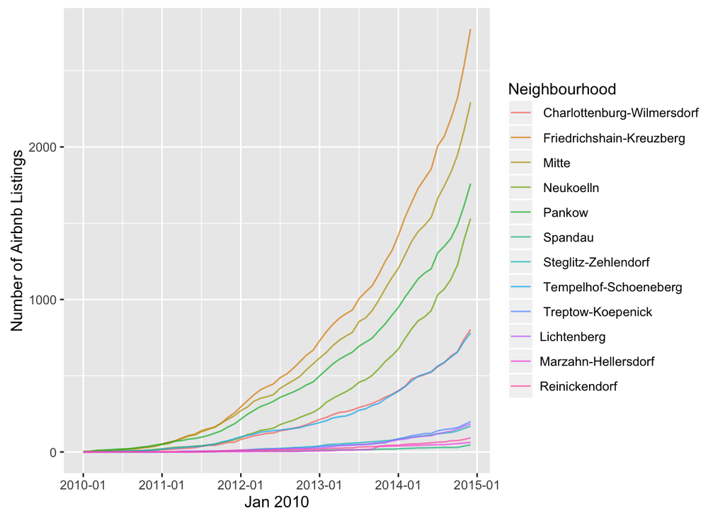

#### But did the increasing number of available apartments in the city really have an effect on hotels?

As you can see, there seems to be a positive relationship between hotel occupancy rate that is the share of beds being in use, and the change in Airbnb supply - even when we looked for the effect on neighbourhood level.

[figure not shown]

### Questions?

Comments and feedback are encouraged, and can be sent to Paulo Kalkhake or Dan Murphy.

### Interested?

Take a look at these papers:

Zervas, Georgios, Davide Proserpio, and John Byers. 2016. “The Rise of the Sharing Economy: Estimating the Impact of Airbnb on the Hotel Industry.” *Boston U. School of Management Research Paper*, no. 2013-16.